# Anomali Tespiti

## Anomali Tespiti Nedir?

> Anomali tespiti, bir veri kümesinde verinin normal davranışına uymayan beklenmedik durumların veya kalıpların bulunması için kullanılan makine öğrenmesi algoritmasıdır.

## Anomali Tespiti Örnekleri

- Dolandırıcılık/Sahtekarlık tespiti
- Hatalı üretim tespiti
- Veri merkezlerindeki bilgisayarların çalışmasının kontrolü

# Algoritmanın Kurulması

Verilen bir veri kümesi için *anomali tespiti* yaparken **Normal Dağılım**dan ya da diğer adıyla **Gauss Dağılımı**ndan yararlanırız.

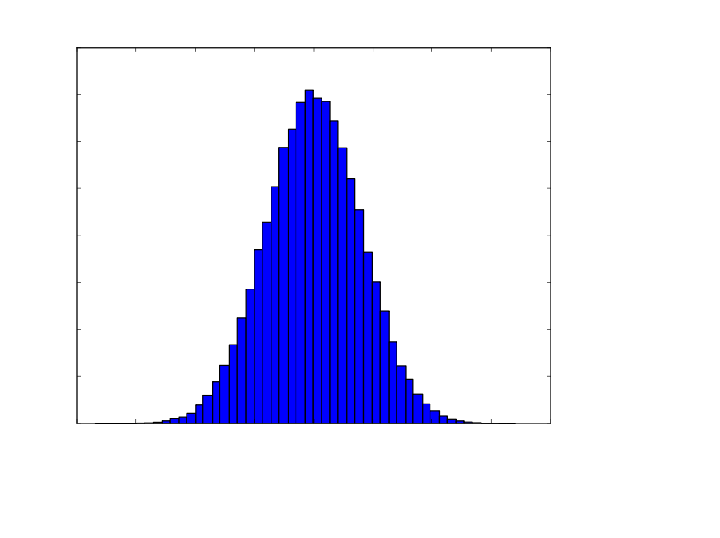

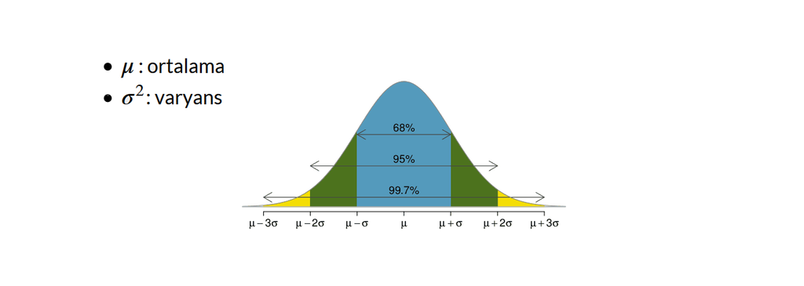

```python
def param(X):

  m =  X.shape[0]
  mu = 1/m * np.sum(X, axis=0)                         # ortalama
  sigma2 = 1/m * np.sum(np.square(X-mu), axis=0)       # varyans

  return mu, sigma2
```

$ \{ x^{(1)}, x^{(2)}, ... , x^{(m)}\}$ şeklinde bir veriseti verildiğinde

$$\begin{align}\displaystyle \mu =\frac{1}{m} \sum_{j=1}^m x^{(j)} \quad \displaystyle \sigma^2 = \frac{1}{m} \sum_{j=1}^m (x^{(j)} - \mu)^2 \end{align}$$

```python
# Normal  dağılım
def gaussian(x, mu, sigma2):        # Girdiler skalar ya da vektor olabilir.

  gaussian = 1/np.sqrt(2 * np.pi * sigma2)*np.exp(-np.square(x-mu)/(2*sigma2))

  return gaussian
```

...ve bu parametrelere karşılık gelen Normal Dağılım

$ \displaystyle p(x, mu, \sigma^2) = \frac{1}{\sqrt{2 \pi \sigma^2 }} \rm{e}^{-\frac{(x-\mu)^2}{2\sigma^2}} $

şeklinde verilir.

[figure not shown]

```python
graph2()
```

## Örnek çalışma: Hatalı sunucuları belirleme

```python
# Örnek 1 (2D)
veri2D = pd.read_csv(r"./ADex1", names=['tepki_suresi', 'akis_hizi'])
veri2D.tail(6)
```

|  | tepki_suresi | akis_hizi |
| --- | --- | --- |
| 301 | 21.727134 | 4.126232 |
| 302 | 12.476629 | 14.459370 |
| 303 | 19.582573 | 10.411619 |
| 304 | 23.339868 | 16.298874 |
| 305 | 18.261188 | 17.978309 |
| 306 | 4.752613 | 24.350407 |

$ \{ x^{(1)}, x^{(2)}, ... , x^{(m)}\}$ örnek için

$x^{(i)}= \left[ x^{(i)}_1,\ x^{(i)}_2,\ ...,\ x^{(i)}_n\right]$ olmak üzere

Kullandığımız veride , $m$ = 307, $n$=2 olup

$x_1=$ Tepki Süresi (ms)

$x_2=$ Veri Akış Hızı (mb/s)

olarak verilmektedir.

Sunucuların Dağılımı

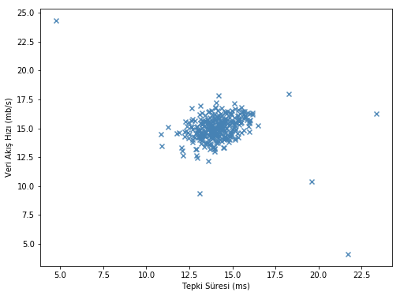

```python
graph3()
```

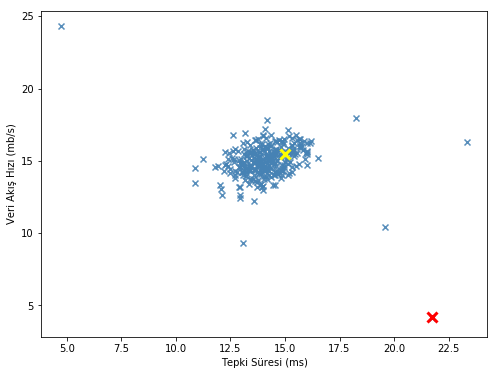

```python
graph5()
```

## Model

Model: $p(x)$

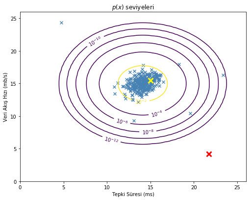

```python
graph6()
```

$$ \begin{cases} p(x) < \epsilon\quad \mbox{ise}\quad \mbox{x anomali }\\ p(x) > \epsilon\quad \mbox{ise}\quad \mbox{x anomali değildir} \end{cases}$$

```python
#  Verilen bir epsilon değeri ve model için anomali tespiti

def anomali_bul(model, epsilon, veri_test):

  pveri = veri_test.apply(model, axis =1)
  anomali_nok = veri_test[(pveri < epsilon)]
  anomali_sayisi = anomali_nok.shape[0]
  print(veri_test.shape[0] , 'veriden', anomali_sayisi, 'tanesi anomalidir.' )

return anomali_nok
```

## Modelin Bulunması

Model fonksiyonu $p(x)$ Normal Dağılım tarafından belirlenir.

$$ \{ x^{(1)}, x^{(2)}, ... , x^{(m)}\}$$

$$x_i=\{x^{(1)}_i, x^{(2)}_i, ... , x^{(m)}_i\}$$

$$\begin{align}\displaystyle \mu_i =&\frac{1}{m} \sum_{j=1}^m x^{(j)}_i\\ \displaystyle \sigma^2_i =& \frac{1}{m} \sum_{j=1}^m (x^{(j)}_i - \mu_i)^2 \end{align}$$

Örneğimizde daha önce de belirttiğimiz üzere $m$ = 307, $n$=2 olup ortalama ve varyans değerlerini

|  | $\mu$ | $\sigma^2$ |
| --- | --- | --- |
| Tepki Süresi | 14.112 | 1.833 |
| Veri Akış Hızı | 14.998 | 1.710 |

olarak bulmuştuk.

Herhangi bir $x$ örneği ya da test verisi için

$$ \displaystyle p(x_i, mu, \sigma^2) =\frac{1}{\sqrt{2 \pi \sigma_i^2 }} \rm{e}^{-\frac{(x_i-\mu_i)^2}{2\sigma_i^2}} $$

olmak üzere

$$ p(x) = \prod_{i=1}^n p(x_i, mu, \sigma^2)$$

şeklinde hesaplanır.

```python
# p(x)'in hesaplanmasi

def model(X):                                         # X = etiketlenmemiş egitme verisi
  mu = param(X)[0]                                    # ortalama
  sigma2 = param(X)[1]                                # varyans
  p_x = lambda x: np.prod(gaussian(x, mu, sigma2))    # olasılık fonksiyonlarının çarpımı
  return p_x                                          # nitelik vektörü ile aynı boyutta vektör alan bir fonksiyon doner
```

```python
# Örnek 1 için model fonksiyonu p(x)
p2D_x = model(veri2D)
```

```python
p2D_x([14,14])
```

```
0.06697300903978197
```

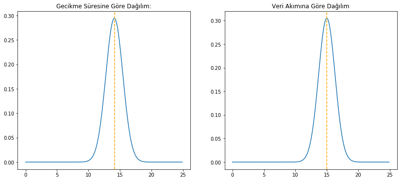

```python
graph4()
```

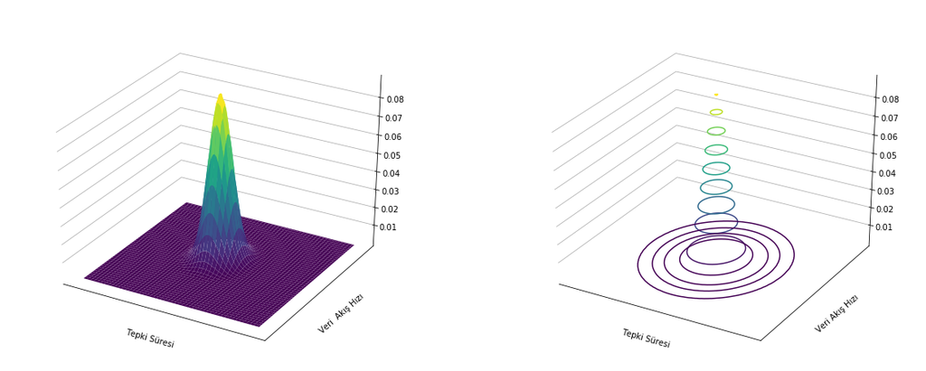

```python
graph7()
```

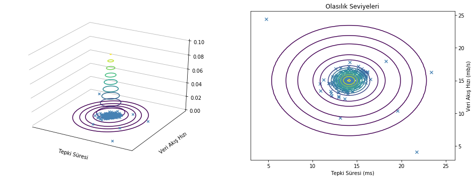

```python
graph8()
```

## Eşik Değeri ($\epsilon$) Seçimi:

Daha önce düzgün çalışmayan sunucuların davranışlarından yola çıkarak etiketlenmiş bir *doğrulama veri kümesi* kullanarak anomalileri belirlemeye çalışacağız.

```python
# Doğrulama veri kümesi(Validation set)
veri2D_dv = pd.read_csv(r"./ADex1_val", names=['tepki_suresi', 'akis_hizi', "anomali"])
veri2D_dv.loc[297:300]
```

|  | tepki_suresi | akis_hizi | anomali |
| --- | --- | --- | --- |
| 297 | 14.293345 | 15.991383 | 0 |
| 298 | 14.952482 | 14.364053 | 0 |
| 299 | 14.734046 | 15.818331 | 0 |
| 300 | 19.289540 | 10.675741 | 1 |

Etiketlenmiş doğrulama verisi

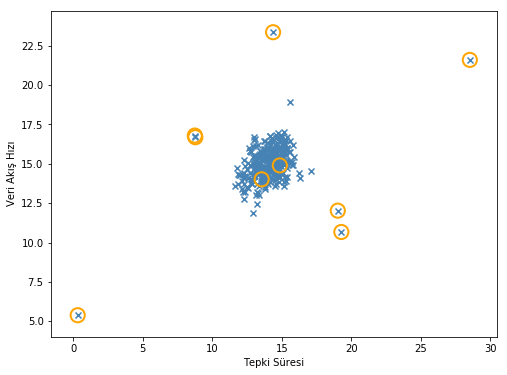

```python
graph9()
```

## Eşik Değeri ($\epsilon$) Seçimi:

### F1 değerlendirme ölçütü

Eşik değerini ne kadar iyi seçtiğimizi belirlerken kesinlik ve hassasiyet arasında iyi bir denge kuran F1 değerlendirme ölçütünü (F1-skoru) kullanacağız.

```python
# F1 skoru hesaplama

def F1(tahmin, y):                                         # Tahmin ve y için  0 ve 1 sayilarindan olusan bir vektor ya da dataframe olarak giriniz.

  dp = len(np.where( (y == 1)  & (tahmin == 1) )[0])       # dogru pozitif
  yp = len(np.where( (y == 0)  & (tahmin == 1) )[0])       # yanlis pozitif
  yn = len(np.where( (y == 1)  & (tahmin == 0) )[0])       # yanlis negatif

  prec = dp/(dp + yp);           # kesinlik
  rec =  dp/(dp + yn);           # hassasiyet
  F1 = 2*(prec*rec)/(prec+rec);  # F1 skoru

  return F1
```

Eşik Değeri Seçme Algoritmamız:

1. Modeli kullanarak doğrulama kümesindeki her x noktası için $p(x)$'i belirle.
2. $min\ p(x)$ ve $max\ p(x)$ arasındaki değerler arasından seçilen her $\epsilon$ için $$ \begin{cases} p(x) < \epsilon\quad \mbox{ise}\quad \mbox{x anomali }\\ p(x) > \epsilon\quad \mbox{ise}\quad \mbox{x anomali değil } \end{cases}$$ olarak işaretleyerek bir tahmin vektörü oluştur.
3. Tahmin ve doğrulama kümesinde verilen gerçek değerleri karşılaştırıp F1 skoru bul.
4. Denenilen $\epsilon$'lardan F1-skoru en büyük olan $\epsilon$'u seç.

```python
# Verilen model ve doğrulama verisine göre epsilon secer:

def epsilon_sec(model, x_dv, y_dv):

  # Dogrulama kumesindeki her x icin p(x) hesaplanir

  p_dv = np.apply_along_axis(model, 1, x_dv) ## numpy array için
  tahmin = p_dv
  bestF1 =0

  for epsilon in np.linspace(p_dv.min(),p_dv.max(), 1000):

    # seçilen epsilona göre anomali tahmini

    tahmin[np.where(p_dv > epsilon)] = 0
    tahmin[np.where(p_dv < epsilon)] = 1
    F1_dv = F1(tahmin, y_dv)

    # en iyi epsilonu secme

    if F1_dv > bestF1:
      bestF1 = F1_dv
      bestEpsilon = epsilon

  return bestEpsilon
```

İncelediğimiz örnekte modelimizin

```
p2D_x = model(veri2D)
```

olarak ve doğrulama veri kümesinin *veri2D_dv* olarak isimlendirdiğimizi hatırlayalım. Bu durumda en iyi epsilon değeri aşağıdaki gibi verilecektir:

```python
epsilon2D= epsilon_sec(p2D_x, veri2D_dv[['tepki_suresi', 'akis_hizi']], veri2D_dv['anomali'])
epsilon2D
```

```
8.999852631901394e-05
```

Anomali bulma fonksiyonumuzu hatırlayalım:

```
def anomali_bul(model, epsilon, veri_test):
...
```

```python
anomali2D= anomali_bul(p2D_x, epsilon2D, veri2D)
anomali2D
```

```
307 veriden 6 tanesi anomalidir.
```

|  | tepki_suresi | akis_hizi |
| --- | --- | --- |
| 300 | 13.079310 | 9.347878 |
| 301 | 21.727134 | 4.126232 |
| 303 | 19.582573 | 10.411619 |
| 304 | 23.339868 | 16.298874 |
| 305 | 18.261188 | 17.978309 |
| 306 | 4.752613 | 24.350407 |

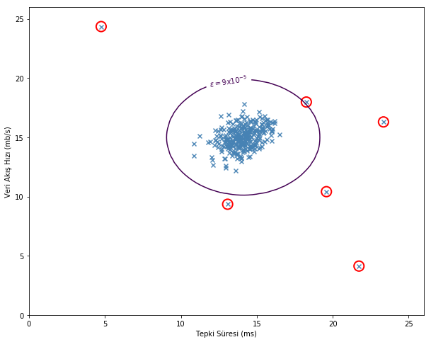

```python
graph10()
```

Özetle anomali tespitini yaparken

1. Verinin dağılıma göre $p(x)$'i belirleriz.
2. Etiketli bir veri kullanarak ya da subjektif olarak eşik değeri seçeriz.
3. Eşik değerini kullanarak anomalileri belirleriz.

**(0)** Verinin okunması

```python
# Örnek 2 (11D): Örnek verinin okunması
## Sütun isimleri
colnames = []
for i in range(1,12):
  colnames.append("Nitelik " + str(i))
veri11D = pd.read_csv(r"./ADex2", names= colnames)
veri11D.sample(4)
```

|  | Nitelik 1 | Nitelik 2 | Nitelik 3 | Nitelik 4 | Nitelik 5 | Nitelik 6 | Nitelik 7 | Nitelik 8 | Nitelik 9 | Nitelik 10 | Nitelik 11 |
| --- | --- | --- | --- | --- | --- | --- | --- | --- | --- | --- | --- |
| 281 | 7.452647 | -12.288335 | 8.642975 | -35.968341 | -11.929317 | 15.112845 | -5.242866 | 19.400414 | -9.721430 | -14.608607 | 4.393329 |
| 960 | 5.531215 | -9.854202 | 28.799444 | -3.093173 | 8.554478 | 16.291028 | -1.758671 | 10.871513 | -9.450252 | -8.757734 | 0.620094 |
| 554 | -2.412726 | -12.044596 | 15.108118 | -1.967563 | -14.637433 | 8.074576 | -9.338133 | 5.095474 | -1.688567 | -9.693132 | 4.361548 |
| 174 | 18.703561 | -1.062856 | -2.673506 | -20.951659 | -11.169384 | 17.254960 | -7.258420 | -3.456287 | 3.849866 | -1.845370 | 5.358850 |

**(1)** Verilen 11 nitelikli veriyi alarak ortalama ve varyans değerlerini hesaplayıp bunlara karşılık gelen model $p(x)$'in hesaplanması

```python
# Model p(x) fonksiyonunun bulunması

p11D_x = model(veri11D)
```

**(2)** Doğrulama verisetini kullanarak eşik değerinin hesaplanması.

```python
# Doğrulama veriseti (Validation set)

colnames_dv = colnames +['Anomali' ]          #y sütunu için isimlendirme
veri2D_dv = pd.read_csv("./ADex2_val", names= colnames_dv)

veri2D_dv.head(4)
```

|  | Nitelik 1 | Nitelik 2 | Nitelik 3 | Nitelik 4 | Nitelik 5 | Nitelik 6 | Nitelik 7 | Nitelik 8 | Nitelik 9 | Nitelik 10 | Nitelik 11 | Anomali |
| --- | --- | --- | --- | --- | --- | --- | --- | --- | --- | --- | --- | --- |
| 0 | 18.271283 | -12.359268 | 5.000970 | 1.611472 | 1.088592 | 29.314410 | -8.313531 | 36.438338 | -9.476679 | -25.928183 | 7.108628 | 1 |
| 1 | -3.193070 | -19.705821 | 6.528556 | -21.570858 | 3.050556 | 23.477503 | -1.133420 | 12.688409 | -10.968301 | -1.198666 | 1.908441 | 0 |
| 2 | -5.256678 | -12.918720 | 25.435141 | -7.231568 | 3.647838 | 12.366550 | -6.512076 | 8.750902 | -0.768755 | -3.261094 | 13.729474 | 0 |
| 3 | 12.953176 | -10.350333 | 19.857858 | -24.424608 | 3.266105 | 30.445294 | -11.125842 | 12.815629 | 9.351355 | -6.113624 | 17.627375 | 1 |

```python
x11D_dv = veri2D_dv.iloc[:, :11]                             # 11 nitelik vektorundan olusan df
y11D_dv = veri2D_dv.iloc[:, 11]                              # gercek deger vektoru

epsilon11D=  epsilon_sec(p11D_x, x11D_dv, y11D_dv)           # esik degeri

print('Eşik değeri', '{:.3E}'.format(epsilon11D), 'olarak bulunmuştur.')
```

```
Eşik değeri 1.379E-18 olarak bulunmuştur.
```

**(3)** Örnek veriseti içinde eşik değerinin dışında kalan noktaları anomali olarak listenmesi:

```python
anomali11D = anomali_bul(p11D_x, epsilon11D, veri11D)
anomali11D
```

```
1000 veriden 117 tanesi anomalidir.
```

|  | Nitelik 1 | Nitelik 2 | Nitelik 3 | Nitelik 4 | Nitelik 5 | Nitelik 6 | Nitelik 7 | Nitelik 8 | Nitelik 9 | Nitelik 10 | Nitelik 11 |
| --- | --- | --- | --- | --- | --- | --- | --- | --- | --- | --- | --- |
| 9 | 15.107877 | -16.430766 | 19.707360 | -19.811888 | -1.644537 | -6.444184 | -6.121214 | 7.042283 | 7.232476 | 17.223479 | -2.956852 |
| 20 | 12.411706 | 3.150959 | 14.827734 | -10.482672 | -8.250082 | -7.982698 | -20.766918 | 30.689476 | 4.622547 | 12.234751 | 23.167294 |
| 21 | 20.946754 | 1.048170 | 8.296324 | -2.595042 | -14.061970 | 8.776611 | -21.886068 | 9.769264 | -20.071130 | 13.871906 | 4.197881 |
| 30 | 5.127033 | -18.517137 | 11.422480 | -28.993408 | -5.797960 | -15.989215 | -12.039753 | 31.296681 | 8.203208 | 8.035668 | 19.519680 |
| 39 | 11.622006 | -0.229723 | 10.005823 | -9.700729 | -14.765493 | 26.933578 | -9.299882 | 13.109171 | 8.976218 | 8.157170 | 18.663064 |
| 56 | -5.689178 | -9.707423 | 22.258180 | 7.890772 | -11.397641 | 34.445407 | -9.836411 | -0.179841 | -13.261052 | 15.200689 | 7.595782 |
| 62 | 16.452993 | -15.320026 | 17.283979 | -5.896654 | -2.940964 | 12.148073 | -3.422623 | 15.684343 | -20.903409 | -0.306900 | -8.481797 |
| 63 | -1.907518 | -10.191011 | 5.041437 | -31.539885 | 0.761368 | 2.671201 | 2.149600 | 11.920996 | -10.353145 | -5.472842 | -7.579770 |
| 69 | -2.665572 | -1.793277 | -3.312666 | -11.771151 | -22.948824 | 0.657702 | 4.040898 | 2.684116 | -4.217029 | -12.993472 | 6.657632 |
| 70 | -2.120839 | -22.573352 | 10.638703 | -2.064867 | 0.942871 | -11.136318 | 1.747898 | 22.794201 | -3.726747 | 4.053987 | -1.185641 |
| 77 | -12.692722 | -11.498905 | 0.026479 | -8.809048 | -16.233664 | -6.701840 | -10.635467 | -8.274253 | -12.428766 | -2.396440 | 9.134138 |
| 79 | 14.552377 | -38.593613 | 19.161298 | -11.379035 | -24.679817 | 29.394102 | -10.255991 | 4.409564 | -20.899036 | -6.997668 | 2.424330 |
| 86 | 3.968173 | -0.948445 | 16.390532 | 4.925583 | -30.252147 | 14.208280 | -11.775899 | 14.966458 | -10.949119 | 0.967746 | 22.231068 |
| 103 | 21.302835 | -22.478786 | 22.219274 | -10.333549 | -15.153760 | 22.316417 | 12.582181 | -0.541537 | -9.436337 | 10.168542 | 7.909259 |
| 130 | 12.981934 | 8.319031 | 19.570986 | -17.000717 | -23.493794 | 16.981319 | 9.996739 | 20.386708 | 3.952619 | -4.310215 | 6.554124 |
| 147 | -14.696577 | -17.209237 | 14.525584 | -20.475409 | 6.159271 | 12.879206 | -13.942417 | 4.008424 | -5.974088 | 17.808364 | 13.138762 |
| 154 | 6.104585 | 3.181527 | -3.318357 | -23.428609 | -14.559891 | 20.376025 | -8.434354 | 6.850325 | -17.518661 | -4.584083 | 5.415755 |
| 166 | 18.829449 | 1.171611 | -0.177123 | -3.604261 | -3.413298 | 19.523349 | 0.903542 | 18.084633 | -11.911412 | -7.921118 | 18.581649 |
| 175 | 8.511318 | -16.107225 | 29.176976 | -21.298302 | -29.855874 | 0.995455 | -7.266977 | 8.159963 | 0.985609 | 7.729459 | -12.966527 |
| 176 | -5.513919 | -6.838657 | 4.026831 | -7.059106 | 0.967883 | 15.205973 | 4.947855 | 5.362446 | -20.477818 | 11.958153 | 16.785018 |
| 198 | 19.861932 | -7.857506 | 5.643955 | -4.439531 | -0.846037 | 26.410503 | -28.741808 | 13.098772 | -14.189061 | -2.010233 | 10.575248 |
| 209 | -10.373139 | -33.577658 | 14.393455 | -3.373885 | -12.078383 | 1.415410 | -6.675364 | -7.337178 | -4.686000 | 3.700622 | 0.949668 |
| 212 | 6.766758 | -4.407579 | 10.305895 | -4.400896 | 6.754287 | 23.584760 | 14.644711 | 16.288997 | -17.195773 | 18.158690 | 2.366239 |
| 218 | 1.081479 | -12.690507 | 31.537406 | 9.477382 | -15.676929 | 1.106263 | -10.324035 | 4.418272 | -19.267674 | 6.174647 | 5.671273 |
| 222 | -15.600509 | -20.351230 | 18.334728 | 10.487489 | -16.037635 | 1.283141 | -8.879621 | 12.140937 | 4.844813 | 2.226241 | -4.970682 |
| 227 | 6.075045 | -23.857709 | 11.693187 | 4.866555 | -11.308274 | -14.698708 | -6.384952 | -10.841639 | -14.239166 | -9.703491 | 4.654031 |
| 229 | 17.438743 | -12.615899 | 0.789213 | 1.746310 | -13.324761 | -4.484684 | -8.728469 | 26.461376 | -13.228487 | 10.545975 | 8.663423 |
| 233 | -0.345422 | -9.868085 | 26.251767 | -25.748620 | -22.168480 | 0.075066 | -4.902324 | 2.772623 | 5.538813 | -10.652863 | 12.019222 |
| 244 | 8.782745 | -11.039724 | 19.792848 | -7.454397 | -11.136051 | -5.493029 | -26.636752 | 14.116266 | -9.001010 | 12.182347 | 21.790293 |
| 262 | 1.815232 | 6.536839 | 15.958974 | 6.231871 | 5.501488 | -4.844246 | 1.442609 | 26.645073 | -15.078784 | -14.621224 | 11.307183 |
| ... | ... | ... | ... | ... | ... | ... | ... | ... | ... | ... | ... |
| 702 | -7.107823 | -2.659451 | -9.913776 | 7.865090 | -15.062972 | -6.669139 | -10.886804 | -5.428388 | -6.145721 | -1.694927 | 36.544551 |
| 705 | 14.410571 | -22.477726 | 3.857208 | -2.952726 | -24.880941 | 26.884771 | -10.301260 | 14.843514 | -5.629550 | 15.834725 | 14.923468 |
| 713 | 2.024200 | -17.995892 | 18.120255 | 9.302085 | -20.657652 | -1.342614 | -18.167920 | -6.761627 | 1.510516 | -0.822743 | 12.133360 |
| 721 | 24.161473 | 2.150718 | 22.656128 | -13.834454 | 4.338249 | -5.126474 | -6.119224 | 3.414971 | 1.066510 | 9.997343 | 27.965546 |
| 741 | -11.113160 | -5.647850 | 23.260981 | 4.848569 | -6.399478 | 18.210016 | 13.164300 | 19.956570 | -0.345878 | 9.654331 | 10.193919 |
| 750 | -11.316527 | -8.600399 | 25.029113 | -2.779305 | -2.414419 | 18.946212 | 2.166333 | -5.778113 | 0.044183 | 4.849727 | 22.058928 |
| 757 | 10.463708 | -21.580878 | 23.946622 | 7.302745 | -22.052180 | 0.784292 | -7.572949 | 6.403820 | -1.567384 | 7.096635 | 21.298699 |
| 758 | -2.731858 | -1.160324 | -1.203266 | -9.844513 | -8.309690 | 27.409155 | 8.013834 | 10.136497 | -16.946208 | 5.646174 | 10.622073 |
| 787 | -0.343405 | -2.980590 | 3.574230 | 10.676147 | -3.662173 | 2.813027 | -21.867923 | -6.557764 | -2.575985 | 3.411594 | 16.251755 |
| 831 | -1.741997 | -1.487631 | 27.069244 | -7.585768 | 2.936218 | 24.616908 | 2.101370 | 41.978198 | -0.526588 | 8.414796 | -1.203203 |
| 834 | -9.546285 | -5.598474 | 16.340206 | -0.153478 | -14.982139 | 2.475574 | -14.791769 | 25.655002 | 2.786267 | -5.184959 | 18.274686 |
| 836 | 12.453219 | -4.065051 | 17.536215 | 7.543518 | 8.571374 | 20.703939 | -18.256704 | 7.374196 | -10.945239 | 0.359840 | -12.650669 |
| 839 | 13.419761 | 7.410299 | 23.401764 | -17.150200 | -8.987999 | 16.752096 | -7.503705 | 20.856191 | 1.770926 | 17.369485 | 14.560195 |
| 846 | -8.993098 | -24.137958 | 8.507993 | -28.898992 | -4.012547 | -2.715727 | -4.027505 | 6.212865 | -15.777059 | 8.403863 | -1.090873 |
| 870 | 7.663754 | -21.315959 | 10.085647 | -13.476459 | 1.869769 | 31.556190 | -4.207739 | 6.783527 | -9.069698 | 25.711498 | 4.205376 |
| 885 | -9.653924 | -10.097966 | 6.088028 | -17.224249 | -35.351822 | 2.677276 | -13.815382 | 10.687653 | -10.804356 | 5.571192 | -9.528244 |
| 887 | 5.591235 | 6.707069 | 25.261202 | 7.251960 | -15.335947 | 6.264382 | -1.493672 | 24.244968 | -4.643058 | 13.628094 | 9.853019 |
| 890 | 5.349885 | -12.919083 | 12.132417 | -30.097538 | -23.687714 | 15.293885 | -7.954287 | 16.382830 | -2.277219 | -12.926472 | 25.837356 |
| 901 | 11.459300 | -6.873557 | 24.064825 | 0.688340 | -14.256252 | -14.539024 | -26.296003 | 18.508660 | -6.114729 | 15.668279 | 0.323248 |
| 911 | -3.840912 | -12.800335 | 1.341582 | -5.303823 | -11.195030 | -0.078478 | 0.028865 | -8.083519 | -21.344629 | 10.631312 | -8.177534 |
| 930 | 12.687826 | -7.989794 | 15.536974 | 6.641290 | 1.062005 | 33.352865 | 6.122964 | 17.815628 | -17.525844 | -2.721404 | 3.446680 |
| 939 | 0.117894 | -24.108314 | 25.600026 | -2.184434 | -26.406851 | 9.524311 | -10.713197 | -1.100855 | -7.452232 | -16.072449 | -1.506024 |
| 940 | -14.471792 | -12.099130 | 17.744803 | -5.173237 | -13.187795 | -3.559686 | -6.379751 | -5.804498 | -10.552952 | 21.174772 | 4.976100 |
| 943 | -8.591807 | -7.044647 | 8.214113 | 4.041871 | -13.361453 | 8.930821 | 6.097335 | -11.421545 | -5.723956 | 12.705342 | 23.809446 |
| 951 | -11.788266 | -11.483627 | 12.438678 | -3.162811 | 0.121983 | 15.905273 | -14.988100 | 15.049161 | -19.249455 | -8.949271 | 16.943905 |
| 952 | -7.514689 | -11.633082 | 12.714199 | -9.659930 | -20.170026 | 46.574569 | -10.498804 | 20.522685 | -1.223742 | 4.478910 | -0.186369 |
| 970 | 8.610956 | -2.087595 | 13.609762 | -5.509457 | 4.565548 | -2.150133 | 6.652794 | 6.604923 | -0.554557 | -21.551409 | 5.522046 |
| 975 | 4.712890 | -5.468014 | 7.463785 | 15.156009 | -4.815854 | -10.092629 | 3.830391 | -0.360002 | -11.221351 | -3.262486 | 1.591322 |
| 992 | -12.120077 | -5.845913 | 28.951978 | -10.215184 | -18.070297 | 15.439734 | -4.961338 | 31.429439 | -7.406423 | 5.847000 | 20.797016 |
| 996 | 3.059507 | -5.926298 | 31.837423 | 0.245340 | 10.050776 | -1.997428 | 2.059449 | 12.571624 | 4.110159 | 14.815644 | 9.035330 |

117 rows × 11 columns

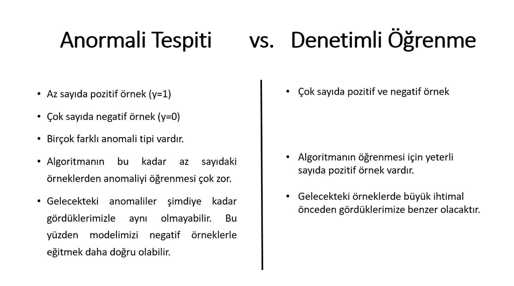

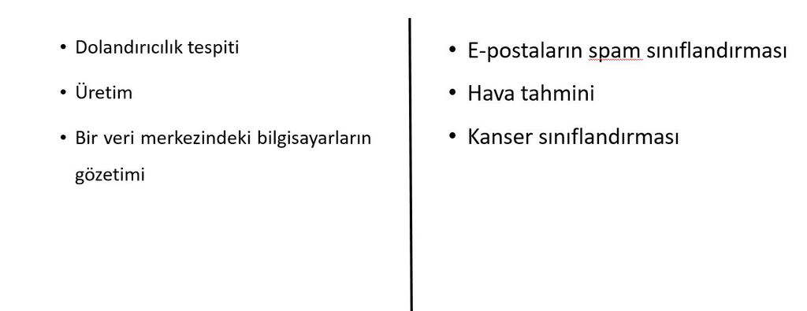